# Data Curation and Visualization using the Tidyverse

Paul Parker

October 19, 2023

## Follow Along

https://github.com/paparker/Data_Curation_and_Viz

## The Tidyverse

The `tidyverse` is a group of packages in the R ecosystem that offer an alternative way to handle and work with data. Some of these packages are

- `readr` for reading and writing data
- `tidyr` for creating tidy data frames
- `dplyr` for manipulating data
- `ggplot2` for data visualization

Most operations require data in the format of a data.frame/tibble.

## Reading in data

```r
library(readr)
pums <- read_csv('../Data/psam_p41.csv')
pums
```

```
## # A tibble: 42,080 × 288
##    RT    SERIALNO   DIVISION SPORDER PUMA  REGION    ST ADJINC PWGTP  AGEP   CIT
##    <chr> <chr>         <dbl> <chr>   <chr>  <dbl> <dbl>  <dbl> <dbl> <dbl> <dbl>
##  1 P     2019GQ000…        9 01      00705      4    41 1.01e6     5    18     1
##  2 P     2019GQ000…        9 01      01301      4    41 1.01e6    68    19     1
##  3 P     2019GQ000…        9 01      00200      4    41 1.01e6    81    37     1
##  4 P     2019GQ000…        9 01      01321      4    41 1.01e6    36    20     1
##  5 P     2019GQ000…        9 01      00300      4    41 1.01e6    66    18     1
##  6 P     2019GQ000…        9 01      00703      4    41 1.01e6    34    85     1
##  7 P     2019GQ000…        9 01      01318      4    41 1.01e6   144    32     1
##  8 P     2019GQ000…        9 01      00200      4    41 1.01e6    88    63     1
##  9 P     2019GQ000…        9 01      00500      4    41 1.01e6    50    37     1
## 10 P     2019GQ000…        9 01      01200      4    41 1.01e6    48    19     1
## # … with 42,070 more rows, and 277 more variables: CITWP <dbl>, COW <dbl>,
## #   DDRS <dbl>, DEAR <dbl>, DEYE <dbl>, DOUT <dbl>, DPHY <dbl>, DRAT <dbl>,
## #   DRATX <dbl>, DREM <dbl>, ENG <dbl>, FER <dbl>, GCL <dbl>, GCM <dbl>,
## #   GCR <dbl>, HIMRKS <dbl>, HINS1 <dbl>, HINS2 <dbl>, HINS3 <dbl>,
## #   HINS4 <dbl>, HINS5 <dbl>, HINS6 <dbl>, HINS7 <dbl>, INTP <dbl>,
## #   JWMNP <dbl>, JWRIP <dbl>, JWTRNS <chr>, LANX <dbl>, MAR <dbl>, MARHD <dbl>,
## #   MARHM <dbl>, MARHT <dbl>, MARHW <dbl>, MARHYP <dbl>, MIG <dbl>, …
```

## Dplyr

Dplyr allows us to manipulate our data:

- `select()` subsets the column space
- `filter()` subsets the row space
- `mutate()` creates new variables/columns
- `group_by()` groups data for future operations
- `summarize()` aggregate data
- `join()` merges data from two sources

## The pipe operator

After loading `dplyr`, you will have access to the pipe operator `%>%` which feeds the argument on the left side as the first argument into the function on the right side.

```r
library(dplyr)
sum(1:10)
```

```
## [1] 55
```

```r
1:10 %>% sum()
```

```
## [1] 55
```

## The pipe operator cont.

This allows for us to read a sequence of operations from left to right as we normally do.

```r
exp(sqrt(sum(1:10)))
```

```
## [1] 1662.701
```

```r
1:10 %>% sum() %>% sqrt() %>% exp()
```

```
## [1] 1662.701
```

## Select

```r
pumsReduced <- pums %>%
  select(PUMA, SALARY=WAGP, WEIGHT=PWGTP, AGE=AGEP, RACE=RAC1P, HICOV, NATIVITY)

pumsFinal <- pumsReduced %>% select(-NATIVITY)
str(pumsFinal)
```

```
## tibble [42,080 × 6] (S3: tbl_df/tbl/data.frame)
##  $ PUMA  : chr [1:42080] "00705" "01301" "00200" "01321" ...
##  $ SALARY: num [1:42080] 12000 5700 0 0 0 0 30000 0 0 1800 ...
##  $ WEIGHT: num [1:42080] 5 68 81 36 66 34 144 88 50 48 ...
##  $ AGE   : num [1:42080] 18 19 37 20 18 85 32 63 37 19 ...
##  $ RACE  : num [1:42080] 1 1 1 1 6 1 1 1 3 9 ...
##  $ HICOV : num [1:42080] 1 1 1 1 1 1 1 1 2 1 ...
```

## Filter

```r
pumsFinal <- pumsFinal %>% filter(SALARY > 0)
str(pumsFinal)
```

```
## tibble [20,566 × 6] (S3: tbl_df/tbl/data.frame)
##  $ PUMA  : chr [1:20566] "00705" "01301" "01318" "01200" ...
##  $ SALARY: num [1:20566] 12000 5700 30000 1800 12000 300 18600 2000 2400 8500 ...
##  $ WEIGHT: num [1:20566] 5 68 144 48 22 27 37 74 70 73 ...
##  $ AGE   : num [1:20566] 18 19 32 19 19 18 21 19 24 21 ...
##  $ RACE  : num [1:20566] 1 1 1 9 9 1 1 9 2 1 ...
##  $ HICOV : num [1:20566] 1 1 1 1 1 1 1 1 2 2 ...
```

```r
pumsFinal %>% filter(RACE %in% 1:3) %>% select(AGE) %>% summary()
```

```
##       AGE
##  Min.   :16.00
##  1st Qu.:31.00
##  Median :43.00
##  Mean   :43.25
##  3rd Qu.:56.00
##  Max.   :95.00
```

## Mutate

```r
pumsFinal <- pumsFinal %>% mutate(WSALARY=WEIGHT*SALARY) %>%
  mutate(RACE=case_when(RACE==1 ~ "White",
                        RACE==2 ~ "Black",
                        RACE==3 ~ "American Indian",
                        RACE==4 ~ "Alaska Native",
                        RACE %in% c(5,8) ~ "Other",
                        RACE==6 ~ "Asian",
                        RACE==7 ~ "Pacific Islander",
                        RACE==9 ~ "Two or more races"))
str(pumsFinal)
```

```
## tibble [20,566 × 7] (S3: tbl_df/tbl/data.frame)
##  $ PUMA   : chr [1:20566] "00705" "01301" "01318" "01200" ...
##  $ SALARY : num [1:20566] 12000 5700 30000 1800 12000 300 18600 2000 2400 8500 ...
##  $ WEIGHT : num [1:20566] 5 68 144 48 22 27 37 74 70 73 ...
##  $ AGE    : num [1:20566] 18 19 32 19 19 18 21 19 24 21 ...
##  $ RACE   : chr [1:20566] "White" "White" "White" "Two or more races" ...
##  $ HICOV  : num [1:20566] 1 1 1 1 1 1 1 1 2 2 ...
##  $ WSALARY: num [1:20566] 60000 387600 4320000 86400 264000 ...
```

## Grouping and summarizing

```r
ests <- pumsFinal %>% group_by(PUMA) %>% summarize(UW=mean(SALARY), HT=sum(WSALARY)/sum(WEIGHT))
ests
```

```
## # A tibble: 31 × 3
##    PUMA      UW     HT
##    <chr>  <dbl>  <dbl>
##  1 00100 38782. 37668.
##  2 00200 42011. 42549.
##  3 00300 35218. 35266.
##  4 00400 46547. 46547.
##  5 00500 41173. 40448.
##  6 00600 40259. 41855.
##  7 00703 39471. 37820.
##  8 00704 42702. 41233.
##  9 00705 44221. 44402.
## 10 00800 36278. 35936.
## # … with 21 more rows
```

## Joins

```r
band_members
```

```
## # A tibble: 3 × 2
##   name  band
##   <chr> <chr>
## 1 Mick  Stones
## 2 John  Beatles
## 3 Paul  Beatles
```

```r
band_instruments
```

```
## # A tibble: 3 × 2
##   name  plays
##   <chr> <chr>
## 1 John  guitar
## 2 Paul  bass
## 3 Keith guitar
```

## Left join

```r
band_members %>% left_join(band_instruments, by="name")
```

```
## # A tibble: 3 × 3
##   name  band    plays
##   <chr> <chr>   <chr>
## 1 Mick  Stones  <NA>
## 2 John  Beatles guitar
## 3 Paul  Beatles bass
```

## Right join

```r
band_members %>% right_join(band_instruments, by="name")
```

```
## # A tibble: 3 × 3
##   name  band    plays
##   <chr> <chr>   <chr>
## 1 John  Beatles guitar
## 2 Paul  Beatles bass
## 3 Keith <NA>    guitar
```

## Inner join

```r
band_members %>% inner_join(band_instruments, by="name")
```

```
## # A tibble: 2 × 3
##   name  band    plays
##   <chr> <chr>   <chr>
## 1 John  Beatles guitar
## 2 Paul  Beatles bass
```

## Full join

```r
band_members %>% full_join(band_instruments, by="name")
```

```
## # A tibble: 4 × 3
##   name  band    plays
##   <chr> <chr>   <chr>
## 1 Mick  Stones  <NA>
## 2 John  Beatles guitar
## 3 Paul  Beatles bass
## 4 Keith <NA>    guitar
```

## Long vs. Wide Data

```r
mice
```

```
##   MouseID Treatment   Before    After
## 1       1     Sugar 3.764528 4.706146
## 2       2     Sugar 3.460512 5.283823
## 3       3     Sugar 3.000373 4.119206
## 4       4  No Sugar 3.144038 3.114809
## 5       5  No Sugar 3.205959 2.886300
## 6       6  No Sugar 3.075126 2.995606
```

```r
library(tidyr)
mice %>%
  pivot_longer(3:4, names_to="Measurement", values_to="Time")
```

[output not shown]

## Long vs. Wide Data Cont.

```r
comps
```

```
## # A tibble: 8 × 3
##   Company Quarter   EPS
##   <chr>   <chr>   <dbl>
## 1 Google  Q1       15.6
## 2 Google  Q2       19.9
## 3 Google  Q3       23.1
## 4 Google  Q4       24.9
## 5 Amazon  Q1        9.8
## 6 Amazon  Q2       12.2
## 7 Amazon  Q3        8.7
## 8 Amazon  Q4       12
```

```r
comps %>% pivot_wider(names_from=Quarter, values_from=EPS)
```

```
## # A tibble: 2 × 5
##   Company    Q1    Q2    Q3    Q4
##   <chr>   <dbl> <dbl> <dbl> <dbl>
## 1 Google   15.6  19.9  23.1  24.9
## 2 Amazon    9.8  12.2   8.7  12
```

## ggplot2

- A graphics package built around a common “grammar”
- Allows flexibility in plotting and ease of use
- Allows the creation of new plots, tailored to the problem at hand

## Data

- To use ggplot, your data must be in the form of a data frame
- We will start with a commonly used data frame, already available with the `ggplot2` package

```r
library(ggplot2)
mpg
```

```
## # A tibble: 234 × 11
##    manufacturer model      displ  year   cyl trans drv     cty   hwy fl    class
##    <chr>        <chr>      <dbl> <int> <int> <chr> <chr> <int> <int> <chr> <chr>
##  1 audi         a4           1.8  1999     4 auto… f        18    29 p     comp…
##  2 audi         a4           1.8  1999     4 manu… f        21    29 p     comp…
##  3 audi         a4           2    2008     4 manu… f        20    31 p     comp…
##  4 audi         a4           2    2008     4 auto… f        21    30 p     comp…
##  5 audi         a4           2.8  1999     6 auto… f        16    26 p     comp…
##  6 audi         a4           2.8  1999     6 manu… f        18    26 p     comp…
##  7 audi         a4           3.1  2008     6 auto… f        18    27 p     comp…
##  8 audi         a4 quattro   1.8  1999     4 manu… 4        18    26 p     comp…
##  9 audi         a4 quattro   1.8  1999     4 auto… 4        16    25 p     comp…
## 10 audi         a4 quattro   2    2008     4 manu… 4        20    28 p     comp…
## # … with 224 more rows
```

## Creating your first plot!

- All plots must start with the `ggplot()` function, this is your canvas
- `aes()` is used to map data components to their correct usage in the plot
- **geom**s can be added sequentially, and specify what type of plot you want

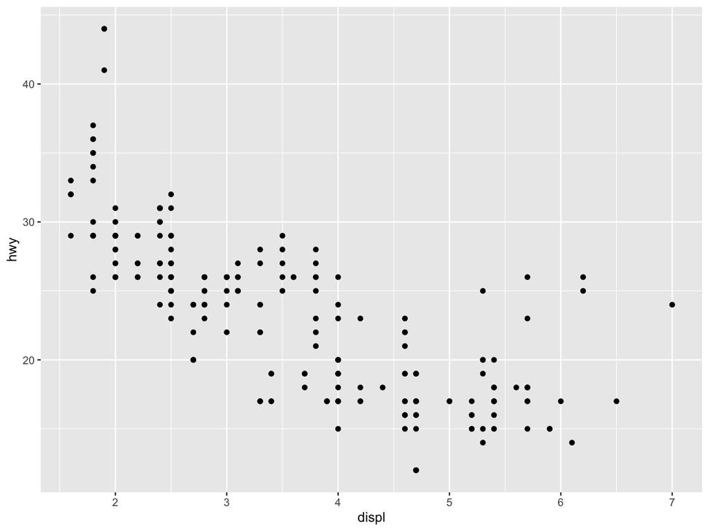

```r
ggplot(mpg, aes(x=displ, y=hwy)) +
  geom_point()
```

How could we add more information to this plot?

## Examples

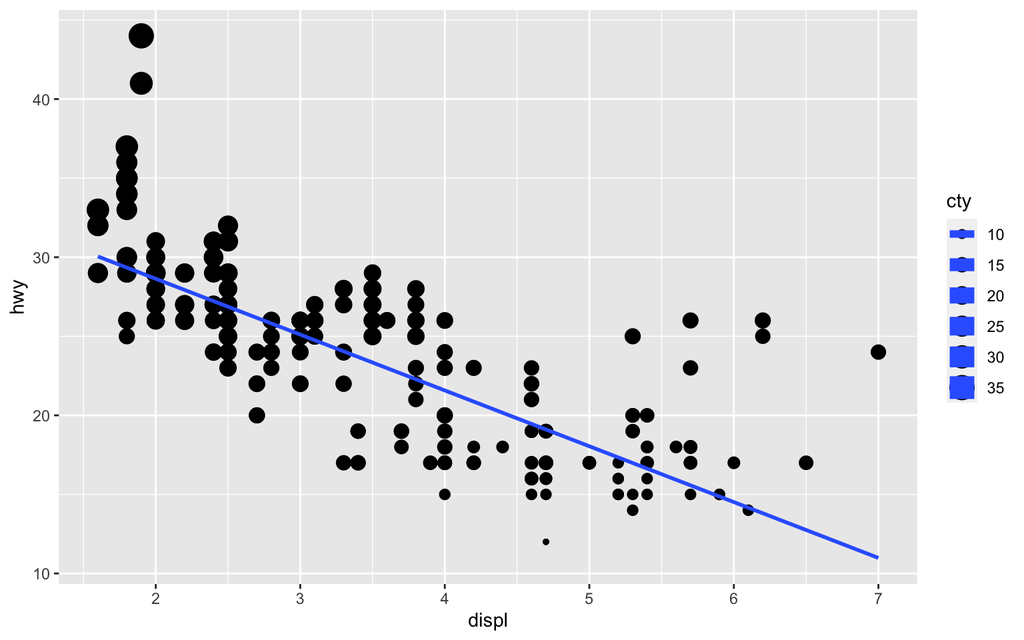

```r
ggplot(mpg, aes(x=displ, y=hwy, size=cty)) +
  geom_point() +
  geom_smooth(method="lm", se=F)
```

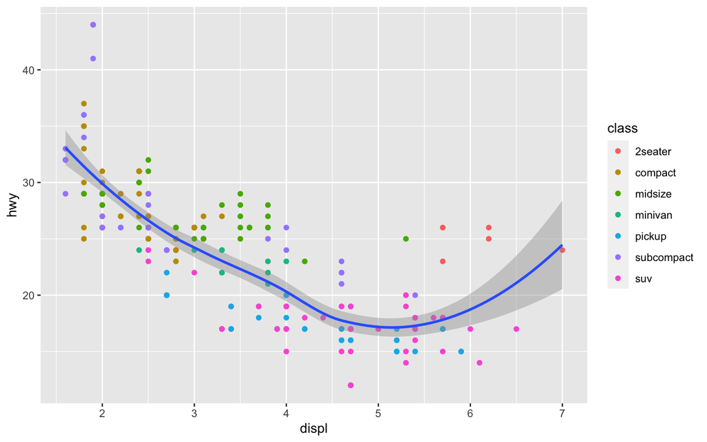

```r
ggplot(mpg, aes(x=displ, y=hwy)) +
  geom_point(aes(color=class)) +
  geom_smooth(method="loess", se=T)
```

Keep iterating!

## Common aesthetics

- **`x`** assigns a variable to the x-axis
- **`y`** assigns a variable to the y-axis
- **`color`** assigns a variable to control the color of geoms
- **`size`** assigns a variable to control the size of geoms
- **`shape`** assigns a variable to control the shape of geoms
- **`alpha`** assigns a variable to control the transparency of geoms
- **`fill`** assigns a variable to control the color that fills in a geom

What if we want to set an aesthetic to a fixed value?

## Fixing aesthetics

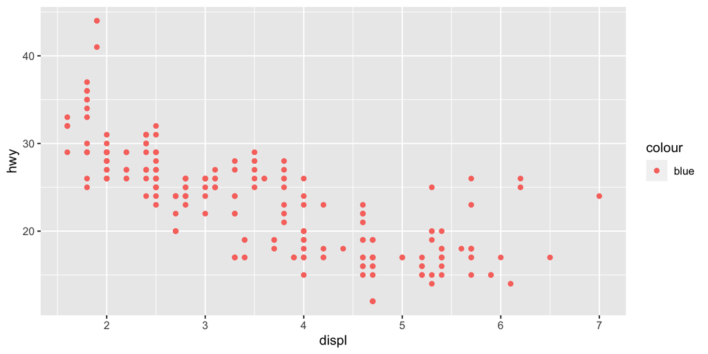

```r
ggplot(mpg, aes(x=displ, y=hwy)) +
  geom_point(aes(color="blue"))
```

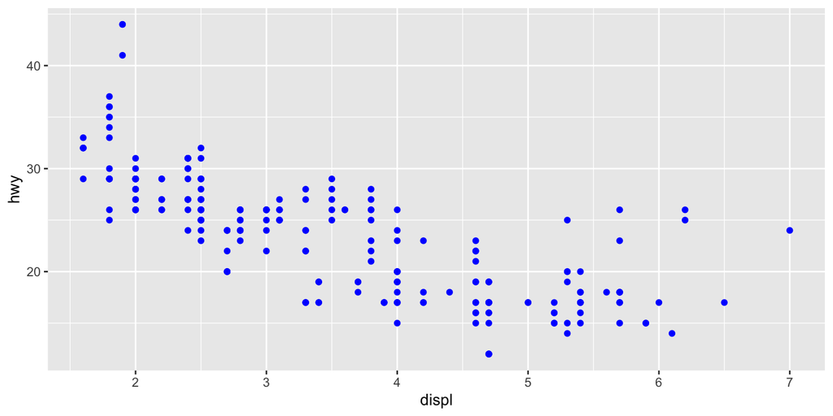

```r
ggplot(mpg, aes(x=displ, y=hwy)) +
  geom_point(color="blue")
```

`aes()` is used to map data to a visual effect, so if you want to fix an aesthetic, keep it outside of the aes function

## Common Geoms

- One variable:
  - **`geom_bar()`** displays counts of a discrete variable via bars
  - **`geom_histogram()`** displays counts of a continuous variable via bars and binning
  - **`geom_density()`** is like a smooth version of a histogram
- Two or more variables:
  - **`geom_point()`** adds points to the plot
  - **`geom_boxplot()`** adds boxplots which can be seperated by group
  - **`geom_violin()`** shows density by group

## geom_bar()

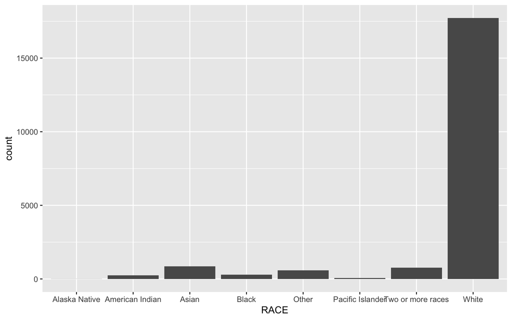

```r
ggplot(pumsFinal, aes(x=RACE)) +
  geom_bar()
```

## geom_histogram()

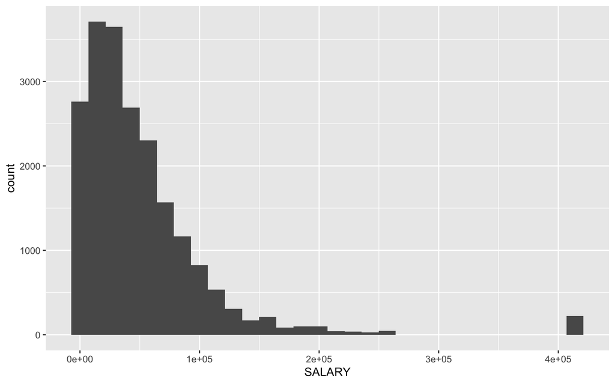

```r
ggplot(pumsFinal, aes(x=SALARY)) +
  geom_histogram()
```

## geom_density()

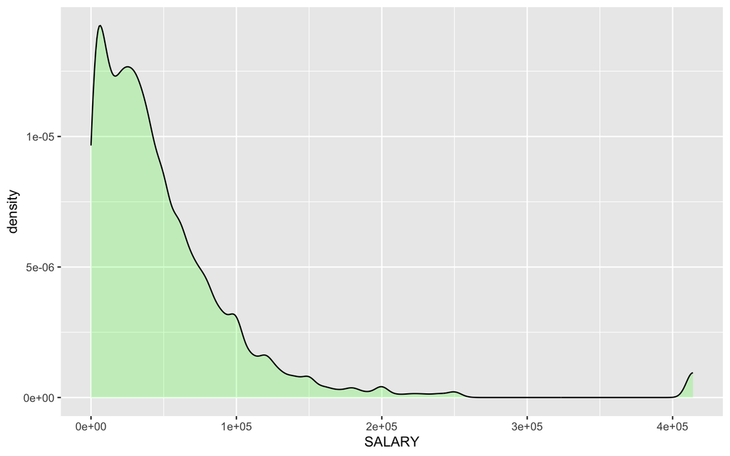

```r
ggplot(pumsFinal, aes(x=SALARY)) +
  geom_density(fill="green", alpha=0.2)
```

## geom_boxplot()

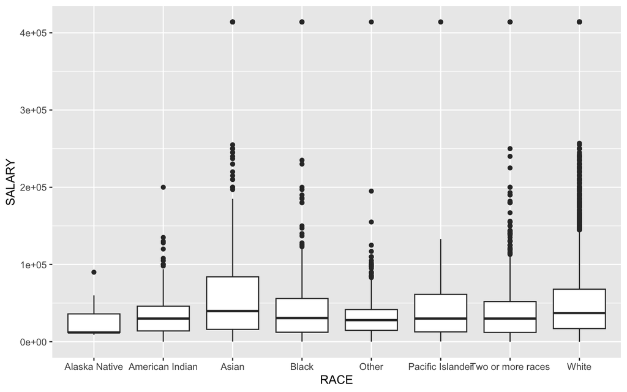

```r
ggplot(pumsFinal, aes(x=RACE, y=SALARY)) +
  geom_boxplot()
```

## geom_violin()

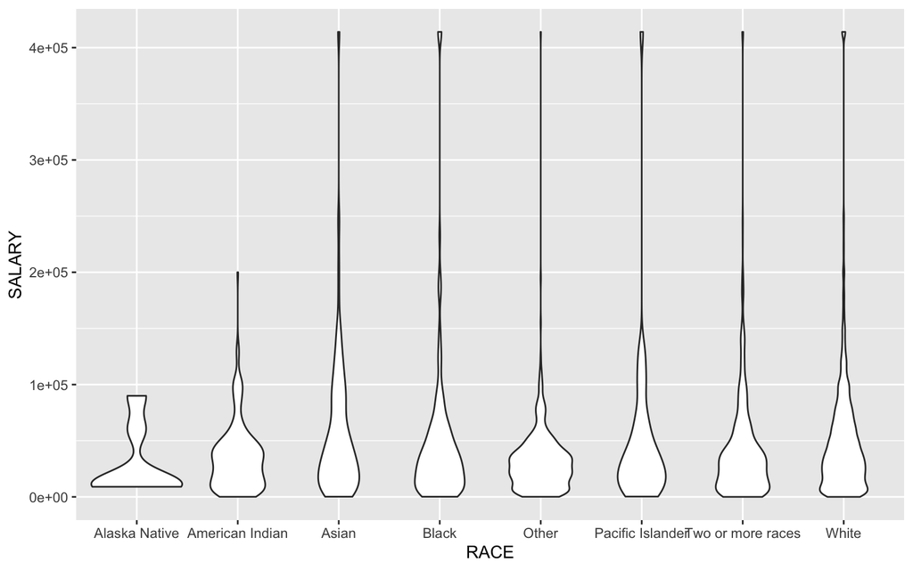

```r
ggplot(pumsFinal, aes(x=RACE, y=SALARY)) +
  geom_violin()
```

## Facet Wrapping

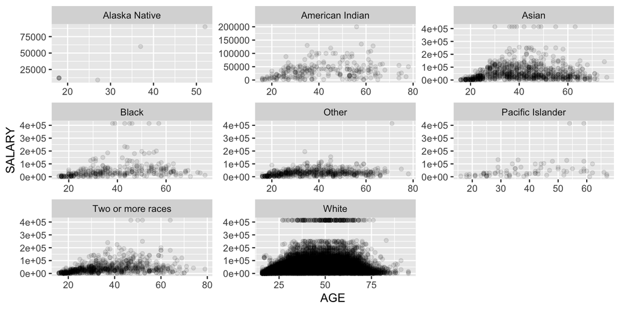

```r
ggplot(pumsFinal, aes(x=AGE, y=SALARY)) +
  geom_point(alpha=0.1) +
  facet_wrap(~RACE, scales='free')
```

## Axes and Title

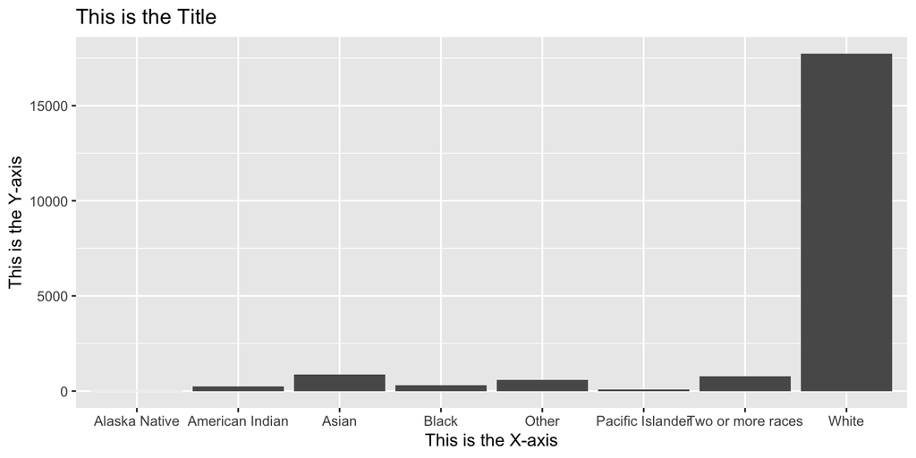

```r
ggplot(pumsFinal, aes(x=RACE)) +
  geom_bar()+
  xlab("This is the X-axis")+
  ylab("This is the Y-axis")+
  ggtitle("This is the Title")
```

## Legends

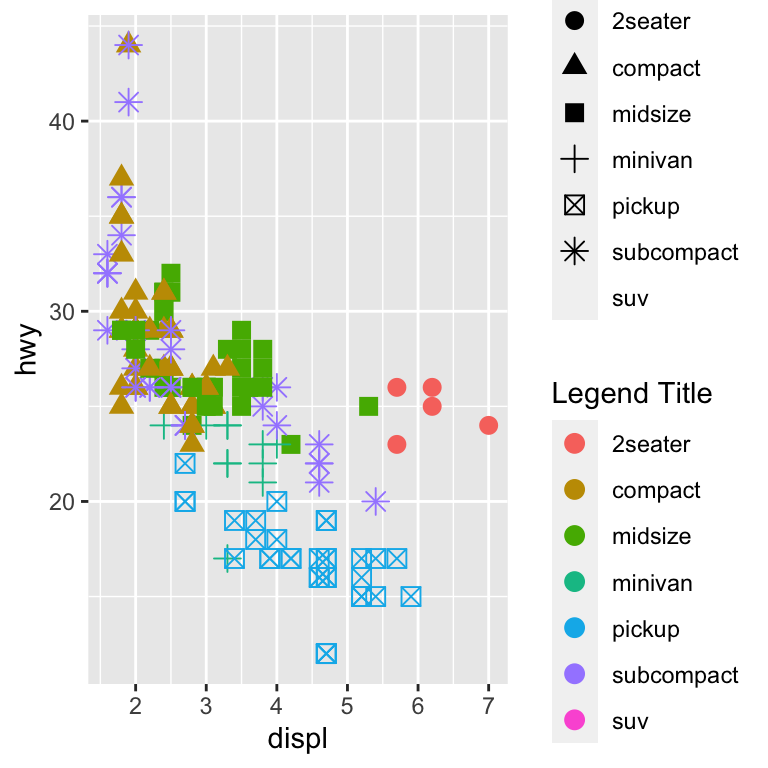

```r
ggplot(mpg, aes(x=displ, y=hwy)) +
  geom_point(size=3, aes(color=class, shape=class))+
  scale_color_discrete(name="Legend Title" )
```

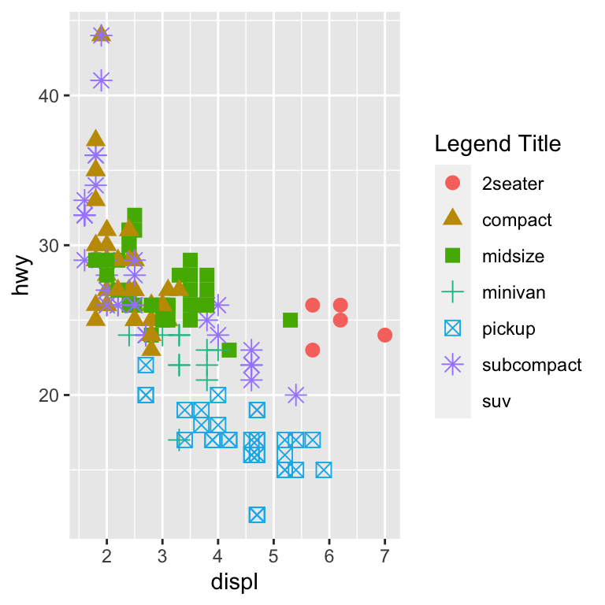

```r
ggplot(mpg, aes(x=displ, y=hwy)) +
  geom_point(size=3, aes(color=class, shape=class))+
  scale_color_discrete(name="Legend Title" )+
  scale_shape_discrete(name="Legend Title")
```

## Labels

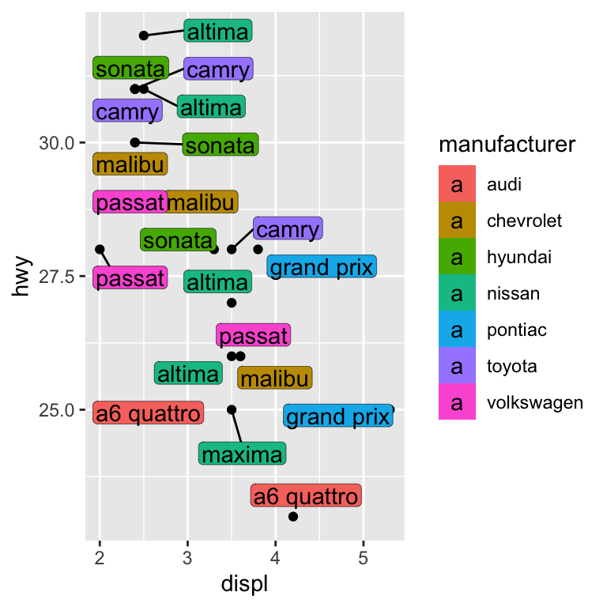

```r
library(ggrepel)
ggplot(mpg %>% filter(class=='midsize' & year==2008),
       aes(x=displ, y=hwy))+
  geom_point()+
  geom_label_repel(label.padding = 0.1, label.size=0.1,
                   aes(label=model, fill=manufacturer))
```

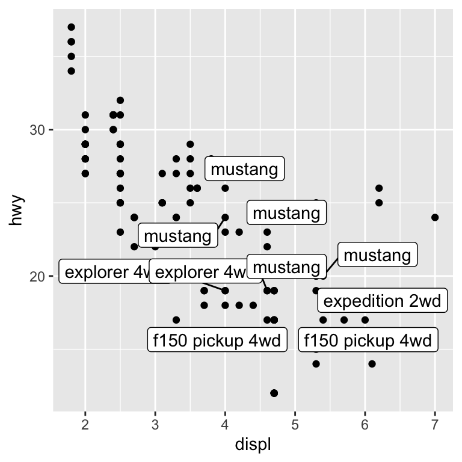

```r
ggplot(mpg %>% filter(year==2008), aes(x=displ, y=hwy))+
  geom_point()+
  geom_label_repel(data=mpg %>%
                     filter(year==2008 & manufacturer=='ford'),
                   aes(label=model))
```

## Themes

There is a package called `ggthemes` that allows you to easiliy change the basic appearance of your plots.

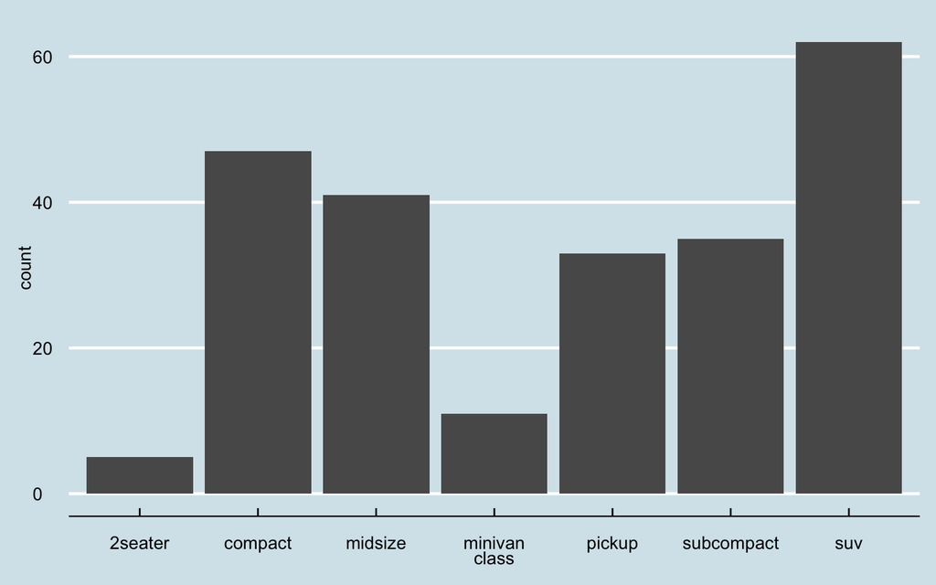

```r
library(ggthemes)
ggplot(mpg, aes(x=class)) +
  geom_bar() +
  theme_economist()
```

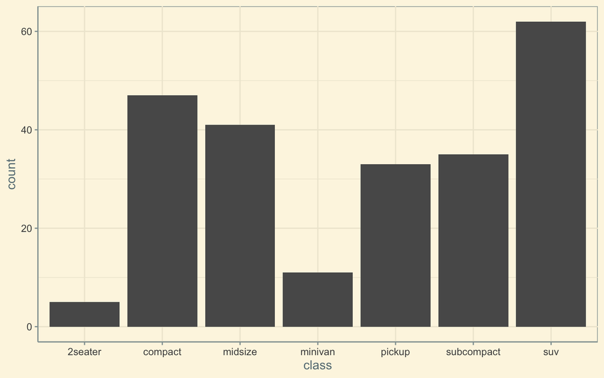

```r
library(ggthemes)
ggplot(mpg, aes(x=class)) +
  geom_bar() +
  theme_solarized()
```

## Maps

When creating maps, you will need to use shape files for the objects you are interested in such as state or county. The `maps` library makes these easy to use for ggplot.

The `map_data` function in this package will create a data frame with the shape files for counties, states, or other options.

## Maps (cont.)

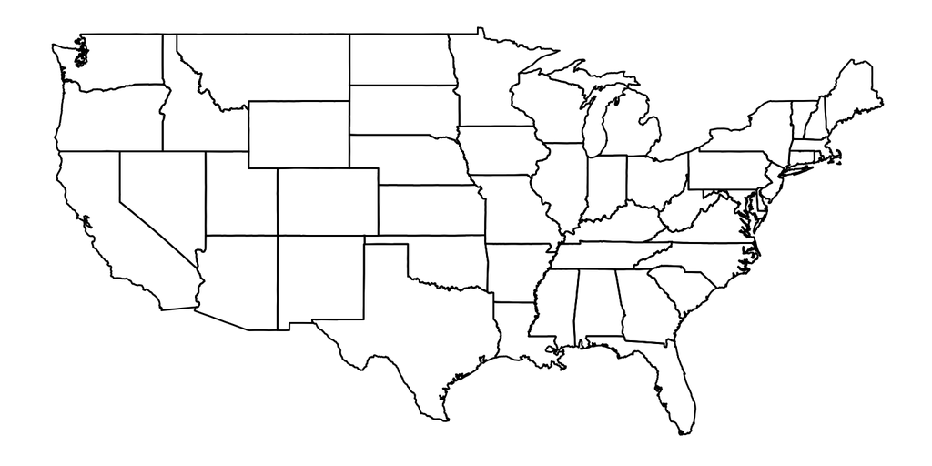

```r
md <- map_data('state')
ggplot(md, aes(x=long, y=lat, group=group))+
  geom_polygon(fill=NA, color='black')+
  theme_map()
```

## Maps (PUMAS)

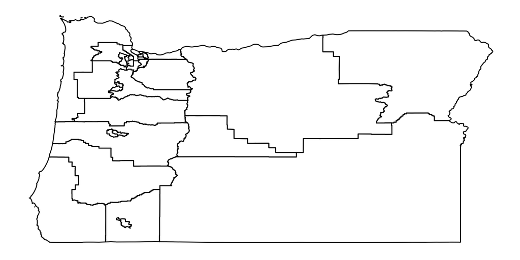

```r
pumasOR <- read_rds('../Data/pumasOR.rds')
ggplot(pumasOR, aes(x=long, y=lat, group=group))+
  geom_polygon(fill=NA, color='black')+
  theme_map()
```

## Maps (PUMAS) Cont.

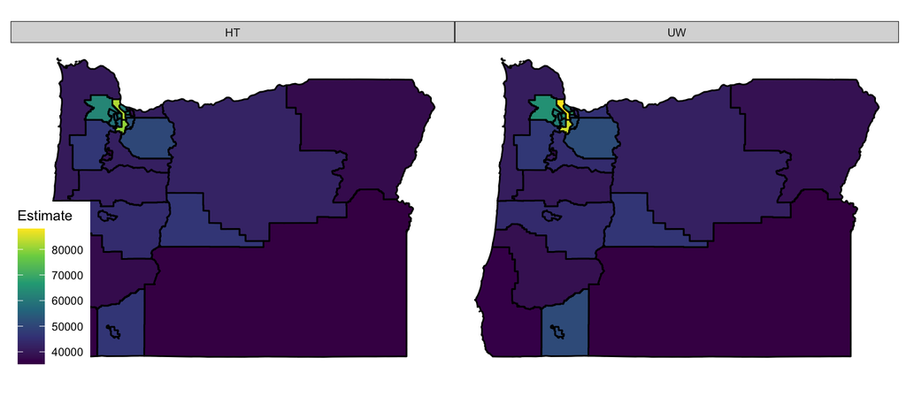

```r
pumasOR <- pumasOR %>% left_join(ests, by=c("id"="PUMA")) %>% pivot_longer(8:9, names_to="Type", values_to="Estimate")
ggplot(pumasOR, aes(x=long, y=lat, group=group))+
  geom_polygon(color='black', aes(fill=Estimate))+
  facet_wrap(~Type, nrow=1)+
  scale_fill_viridis_c()+
  coord_map()+
  theme_map()
```

## Animations

There is a package called `gganimate` that makes it really easy to create animations using ggplot objects. You just need to create a ggplot object and add `transition_states` based on some variable.

```r
tsACS <- read_rds('../Data/tsACS.rds')

library(gganimate)
p1 <- ggplot()+
  geom_polygon(data=tsACS,
           aes(x=long, y=lat, group=group, fill=estimate),
           color="black",  size=0.25)+
  theme_map()+
  coord_map()+
  scale_fill_viridis_c(name="Average Income")+
  theme(legend.position="right",plot.title = element_text(hjust = 0.5,face="bold"))+
  labs(title = "Average Income by County in {closest_state}") +
  transition_states(Year, transition_length = 2, state_length = 1)
animate(p1)
```

## Animations (cont.)

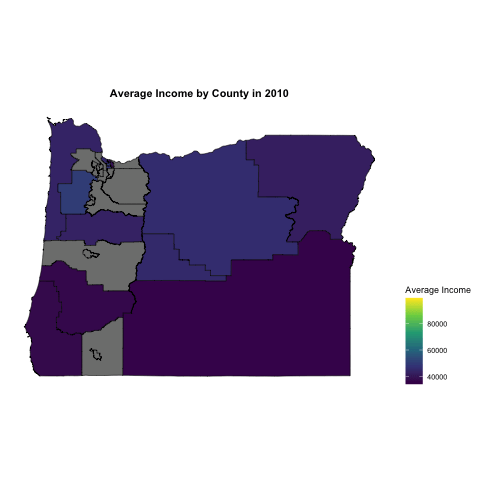

## Shiny

[interactive chart not shown]

## Shiny Example

[interactive chart not shown]

https://paparker.shinyapps.io/shape_app/

## Thank you!

paulparker@ucsc.edu